# TK_KASDD_Spotify_1

## Import Data

```python
# library
%pip install imbalanced-learn
import numpy as np
import pandas as pd
import seaborn as sns
import matplotlib.pyplot as plt
pd.options.display.max_rows = 4000
import warnings
warnings.filterwarnings('ignore')
```

```python
data_1950 = pd.read_csv("1950.csv")
data_1950.head()
```

|  | title | artist | genre | year | bpm | nrgy | dnce | dB | live | val | dur | acous | spch | popularity | has_win_award |
| --- | --- | --- | --- | --- | --- | --- | --- | --- | --- | --- | --- | --- | --- | --- | --- |
| 0 | Put Your Head On My Shoulder | Paul Anka | adult standards | 2000 | 116 | 34 | 55 | -9 | 10 | 47 | 155 | 75 | 3 | 72 | 0.0 |
| 1 | Whatever Will Be Will Be (Que Sera Sera) (with... | Doris Day | adult standards | 1948 | 177 | 34 | 42 | -11 | 72 | 78 | 123 | 86 | 4 | 62 | 0.0 |
| 2 | Everybody Loves Somebody | Dean Martin | adult standards | 2013 | 81 | 49 | 26 | -9 | 34 | 40 | 162 | 81 | 4 | 61 | 0.0 |
| 3 | Take Good Care Of My Baby - 1990 Remastered | Bobby Vee | adult standards | 2011 | 82 | 43 | 49 | -12 | 12 | 66 | 151 | 70 | 6 | 60 | 0.0 |
| 4 | A Teenager In Love | Dion & The Belmonts | adult standards | 1959 | 79 | 38 | 56 | -9 | 13 | 62 | 158 | 67 | 3 | 60 | 0.0 |

```python
data_1960 = pd.read_csv("1960.csv")
data_1960.head()
```

|  | title | artist | genre | year | bpm | nrgy | dnce | dB | live | val | dur | acous | spch | popularity | has_win_award |
| --- | --- | --- | --- | --- | --- | --- | --- | --- | --- | --- | --- | --- | --- | --- | --- |
| 0 | Here Comes The Sun - Remastered 2009 | The Beatles | british invasion | 1969 | 129 | 54 | 56 | -10 | 18 | 39 | 186 | 3 | 3 | 82 | 1.0 |
| 1 | Come Together - Remastered 2009 | The Beatles | british invasion | 1969 | 165 | 38 | 53 | -12 | 9 | 19 | 260 | 3 | 4 | 79 | 0.0 |
| 2 | Sweet Caroline | Neil Diamond | adult standards | 1969 | 63 | 13 | 53 | -16 | 24 | 58 | 204 | 61 | 3 | 78 | 0.0 |
| 3 | Yesterday - Remastered 2009 | The Beatles | british invasion | 1965 | 97 | 18 | 33 | -12 | 9 | 32 | 126 | 88 | 3 | 78 | 0.0 |
| 4 | Can't Help Falling in Love | Elvis Presley | adult standards | 1961 | 100 | 29 | 40 | -14 | 11 | 34 | 182 | 94 | 3 | 78 | 0.0 |

```python
data_1970 = pd.read_csv("1970.csv")
data_1970.head()
```

|  | title | artist | genre | year | bpm | nrgy | dnce | dB | live | val | dur | acous | spch | popularity | has_win_award |
| --- | --- | --- | --- | --- | --- | --- | --- | --- | --- | --- | --- | --- | --- | --- | --- |
| 0 | Bohemian Rhapsody - 2011 Mix | Queen | glam rock | 1975 | 71 | 40 | 41 | -10 | 30 | 22 | 354 | 27 | 5 | 84 | 1.0 |
| 1 | Highway to Hell | AC/DC | album rock | 1979 | 116 | 91 | 57 | -5 | 16 | 42 | 208 | 6 | 13 | 83 | 0.0 |
| 2 | Don't Stop Me Now - 2011 Mix | Queen | glam rock | 1978 | 156 | 87 | 56 | -5 | 78 | 61 | 209 | 5 | 17 | 82 | 1.0 |
| 3 | Rocket Man (I Think It's Going To Be A Long Lo... | Elton John | glam rock | 1972 | 137 | 53 | 60 | -9 | 9 | 34 | 282 | 43 | 3 | 81 | 1.0 |
| 4 | We Will Rock You - Remastered | Queen | glam rock | 1977 | 81 | 50 | 69 | -7 | 26 | 48 | 122 | 68 | 12 | 79 | 0.0 |

```python
data_1980 = pd.read_csv("1980.csv")
data_1980.head()
```

|  | title | artist | genre | year | bpm | nrgy | dnce | dB | live | val | dur | acous | spch | popularity | has_win_award |
| --- | --- | --- | --- | --- | --- | --- | --- | --- | --- | --- | --- | --- | --- | --- | --- |
| 0 | Livin' On A Prayer | Bon Jovi | glam metal | 1986 | 123 | 89 | 53 | -4 | 29 | 80 | 249 | 8 | 3 | 83 | 0.0 |
| 1 | Africa | TOTO | album rock | 1982 | 93 | 37 | 67 | -18 | 5 | 73 | 296 | 26 | 3 | 83 | 1.0 |
| 2 | Another One Bites The Dust - Remastered 2011 | Queen | glam rock | 1980 | 110 | 53 | 93 | -6 | 16 | 75 | 215 | 11 | 16 | 82 | 1.0 |
| 3 | Break My Stride | Matthew Wilder | new wave pop | 1983 | 110 | 59 | 92 | -11 | 9 | 83 | 184 | 20 | 6 | 81 | 1.0 |
| 4 | I Wanna Dance with Somebody (Who Loves Me) | Whitney Houston | dance pop | 1987 | 119 | 82 | 71 | -9 | 9 | 87 | 291 | 21 | 5 | 80 | 1.0 |

```python
data_1990 = pd.read_csv("1990.csv")
data_1990.head()
```

|  | title | artist | genre | year | bpm | nrgy | dnce | dB | live | val | dur | acous | spch | popularity | has_win_award |
| --- | --- | --- | --- | --- | --- | --- | --- | --- | --- | --- | --- | --- | --- | --- | --- |
| 0 | No Scrubs | TLC | atl hip hop | 1999 | 93 | 68 | 74 | -4 | 7 | 59 | 214 | 3 | 10 | 79 | 0.0 |
| 1 | I Want It That Way | Backstreet Boys | boy band | 2001 | 99 | 70 | 69 | -6 | 16 | 48 | 214 | 22 | 3 | 76 | 0.0 |
| 2 | It Wasn't Me | Shaggy | dance pop | 2000 | 95 | 61 | 85 | -5 | 31 | 65 | 228 | 6 | 7 | 76 | 0.0 |
| 3 | Because You Loved Me (Theme from "Up Close and... | CÃ©line Dion | canadian pop | 1996 | 120 | 47 | 61 | -10 | 10 | 18 | 274 | 31 | 3 | 74 | 0.0 |
| 4 | Big Poppa - 2005 Remaster | The Notorious B.I.G. | east coast hip hop | 1994 | 84 | 58 | 78 | -7 | 14 | 76 | 253 | 43 | 27 | 74 | 0.0 |

```python
data_2000 = pd.read_csv("2000.csv")
data_2000.head(10)
```

|  | title | artist | genre | year | bpm | nrgy | dnce | dB | live | val | dur | acous | spch | popularity | has_win_award |
| --- | --- | --- | --- | --- | --- | --- | --- | --- | --- | --- | --- | --- | --- | --- | --- |
| 0 | In the End | Linkin Park | alternative metal | 2000 | 105 | 86 | 56 | -6 | 21 | 40 | 217 | 1 | 6 | 83 | 1.0 |
| 1 | The Scientist | Coldplay | permanent wave | 2002 | 146 | 44 | 56 | -7 | 11 | 21 | 310 | 73 | 2 | 83 | 1.0 |
| 2 | Numb | Linkin Park | alternative metal | 2003 | 110 | 86 | 50 | -4 | 64 | 24 | 186 | 0 | 4 | 81 | 1.0 |
| 3 | Fix You | Coldplay | permanent wave | 2005 | 138 | 42 | 21 | -9 | 11 | 12 | 296 | 16 | 3 | 81 | 1.0 |
| 4 | Umbrella | Rihanna | barbadian pop | 2008 | 174 | 83 | 58 | -5 | 4 | 57 | 276 | 1 | 13 | 80 | 0.0 |
| 5 | Stronger | Kanye West | chicago rap | 2007 | 104 | 72 | 62 | -8 | 41 | 49 | 312 | 1 | 15 | 80 | 1.0 |
| 6 | The Real Slim Shady | Eminem | detroit hip hop | 2000 | 105 | 66 | 95 | -4 | 5 | 76 | 284 | 3 | 6 | 80 | 1.0 |
| 7 | Low (feat. T-Pain) | Flo Rida | dance pop | 2008 | 128 | 61 | 92 | -6 | 14 | 30 | 231 | 9 | 8 | 79 | 0.0 |
| 8 | American Boy | Estelle | r&b | 2008 | 118 | 73 | 73 | -3 | 7 | 51 | 285 | 17 | 33 | 79 | 0.0 |
| 9 | Yeah! (feat. Lil Jon & Ludacris) | Usher | atl hip hop | 2004 | 105 | 79 | 89 | -5 | 4 | 58 | 250 | 2 | 11 | 79 | 0.0 |

```python
data_2010 = pd.read_csv("2010.csv")
data_2010.head()
```

|  | title | artist | genre | year | bpm | nrgy | dnce | dB | live | val | dur | acous | spch | popularity | has_win_award |
| --- | --- | --- | --- | --- | --- | --- | --- | --- | --- | --- | --- | --- | --- | --- | --- |
| 0 | bad guy | Billie Eilish | electropop | 2019 | 135 | 43 | 70 | -11 | 10 | 56 | 194 | 33 | 38 | 94 | 0.0 |
| 1 | 7 rings | Ariana Grande | dance pop | 2019 | 140 | 32 | 78 | -11 | 9 | 33 | 179 | 59 | 33 | 90 | 1.0 |
| 2 | Old Town Road - Remix | Lil Nas X | country rap | 2019 | 136 | 62 | 88 | -6 | 11 | 64 | 157 | 5 | 10 | 89 | 1.0 |
| 3 | SeÃ±orita | Shawn Mendes | canadian pop | 2019 | 117 | 55 | 76 | -6 | 8 | 75 | 191 | 4 | 3 | 88 | 1.0 |
| 4 | rockstar (feat. 21 Savage) | Post Malone | dfw rap | 2018 | 160 | 52 | 59 | -6 | 13 | 13 | 218 | 12 | 7 | 88 | 1.0 |

```python
data_top10 = pd.read_csv("top10s.csv")
data_top10.head()
```

|  | title | artist | genre | year | bpm | nrgy | dnce | dB | live | val | dur | acous | spch | popularity | has_win_award |
| --- | --- | --- | --- | --- | --- | --- | --- | --- | --- | --- | --- | --- | --- | --- | --- |
| 0 | Love The Way You Lie | Eminem | detroit hip hop | 2010 | 87 | 93 | 75 | -5 | 52 | 64 | 263 | 24 | 23 | 82 | 1.0 |
| 1 | TiK ToK | Kesha | dance pop | 2010 | 120 | 84 | 76 | -3 | 29 | 71 | 200 | 10 | 14 | 80 | 0.0 |
| 2 | Bad Romance | Lady Gaga | dance pop | 2010 | 119 | 92 | 70 | -4 | 8 | 71 | 295 | 0 | 4 | 79 | 0.0 |
| 3 | Just the Way You Are | Bruno Mars | pop | 2010 | 109 | 84 | 64 | -5 | 9 | 43 | 221 | 2 | 4 | 78 | 0.0 |
| 4 | Baby | Justin Bieber | canadian pop | 2010 | 65 | 86 | 73 | -5 | 11 | 54 | 214 | 4 | 14 | 77 | 0.0 |

```python
data_year = [data_1950, data_1960, data_1970, data_1980, data_1990, data_2000, data_2010, data_top10]
year = ["1950", "1960", "1970", "1980", "1990", "2000", "2010", "top 10 2010"]
```

## Data Preprocessing

### Cek Null

```python
def cek_null(df):
    col_na = df.isnull().sum().sort_values(ascending=False)
    percent = col_na / len(df)
    missing_data = pd.concat([col_na, percent], axis=1, keys=['Total', 'Percent'])
    print(missing_data[missing_data['Total'] > 0])
```

```python
for idx, data in enumerate(data_year):
    print("Penanganan data untuk dekade", year[idx])
    cek_null(data)
    # Isi data null dengan mode nya
    data['genre'].fillna(data['genre'].mode()[0],inplace = True)
    print("==== Setelah Diisi ====")
    cek_null(data)
    print("\n")
```

```
Penanganan data untuk dekade 1950
       Total   Percent
genre     12  0.164384
==== Setelah Diisi ====
Empty DataFrame
Columns: [Total, Percent]
Index: []


Penanganan data untuk dekade 1960
Empty DataFrame
Columns: [Total, Percent]
Index: []
==== Setelah Diisi ====
Empty DataFrame
Columns: [Total, Percent]
Index: []


Penanganan data untuk dekade 1970
Empty DataFrame
Columns: [Total, Percent]
Index: []
==== Setelah Diisi ====
Empty DataFrame
Columns: [Total, Percent]
Index: []


Penanganan data untuk dekade 1980
       Total   Percent
genre      1  0.009524
==== Setelah Diisi ====
Empty DataFrame
Columns: [Total, Percent]
Index: []


Penanganan data untuk dekade 1990
       Total   Percent
```

[output cut: 20 more lines]

```
Index: []
==== Setelah Diisi ====
Empty DataFrame
Columns: [Total, Percent]
Index: []


Penanganan data untuk dekade top 10 2010
Empty DataFrame
Columns: [Total, Percent]
Index: []
==== Setelah Diisi ====
Empty DataFrame
Columns: [Total, Percent]
Index: []
```

```python
data_all_year = pd.DataFrame()
for idx, data in enumerate(data_year):
    data_all_year = data_all_year.append(data, ignore_index = True)
```

### Cek Duplicated Row

```python
for idx, data in enumerate(data_year):
    dup = data.duplicated().sum()
    print("Terdapat", dup, "duplikat pada data di dekade", year[idx]) # Memperlihatkan jumlah baris duplikat
```

```
Terdapat 0 duplikat pada data di dekade 1950
Terdapat 0 duplikat pada data di dekade 1960
Terdapat 0 duplikat pada data di dekade 1970
Terdapat 0 duplikat pada data di dekade 1980
Terdapat 0 duplikat pada data di dekade 1990
Terdapat 0 duplikat pada data di dekade 2000
Terdapat 0 duplikat pada data di dekade 2010
Terdapat 0 duplikat pada data di dekade top 10 2010
```

### Cek Outlier

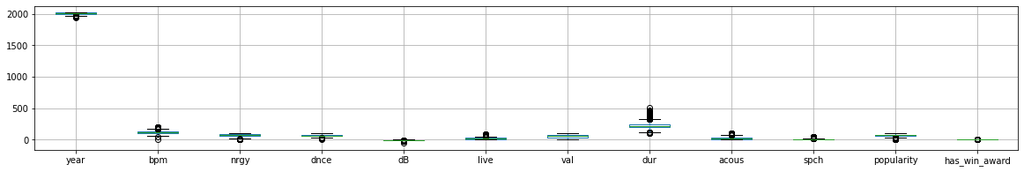

```python
display(data_all_year.boxplot(figsize=(20,3)))
```

```python
Q1 = data_all_year.quantile(0.25)
Q3 = data_all_year.quantile(0.75)
IQR = Q3 - Q1

df_outlier = (data_all_year < (Q1 - 1.5 * IQR)) | (data_all_year > (Q3 + 1.5 * IQR))
df_outlier.sum()
```

```
acous             86
artist             0
bpm               40
dB                36
dnce              11
dur               55
genre              0
has_win_award    129
live              61
nrgy              10
popularity        23
spch             116
title              0
val                0
year              60
dtype: int64
```

```python
arr = ['title','artist', 'genre', 'has_win_award', 'year']

for c in data_all_year.columns:
    if c not in arr:
        data = data_all_year[c]
        Q1_column = data.quantile(0.25)
        Q3_column = data.quantile(0.75)
        IQR_column = Q3_column - Q1_column
        mask = data_all_year.loc[(data < (Q1_column - 1.5 * IQR_column)) | (data > (Q3_column + 1.5 * IQR_column))]
        #if c == 'acous':
        #    data_all_year = data_all_year.drop(data_all_year[(data_all_year[c] < (Q1_column - 1.5 * IQR_column)) | (data_all_year[c] > (Q3_column + 1.5 * IQR_column))].index)
        #else:
        data_all_year.loc[mask.index, c] = data.mean(skipna=True)

    else:
        continue
```

```python
df_outlier = (data_all_year < (Q1 - 1.5 * IQR)) | (data_all_year > (Q3 + 1.5 * IQR))
df_outlier.sum()
```

```
acous              0
artist             0
bpm                0
dB                 0
dnce               0
dur                0
genre              0
has_win_award    129
live               0
nrgy               0
popularity         0
spch               0
title              0
val                0
year              60
dtype: int64
```

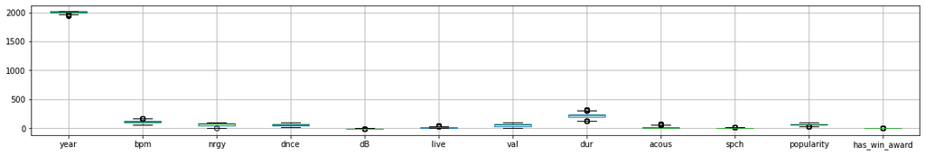

```python
display(data_all_year.boxplot(figsize=(20,3)))
```

## Data Analysis

### Artis paling Populer

```python
for idx, data in enumerate(data_year):
    sum_popularity = data.groupby(by=["artist"]).sum()
    sum_popularity.sort_values(by='popularity', inplace=True, ascending=False)
    first = sum_popularity.iloc[0]
    print("Artis paling populer dari dataset", year[idx], "adalah", first.name, "dengan total nilai popularitas sebesar", first.popularity)
```

```
Artis paling populer dari dataset 1950 adalah Dean Martin dengan total nilai popularitas sebesar 147.0
Artis paling populer dari dataset 1960 adalah The Beatles dengan total nilai popularitas sebesar 446.0
Artis paling populer dari dataset 1970 adalah Queen dengan total nilai popularitas sebesar 588.0
Artis paling populer dari dataset 1980 adalah Madonna dengan total nilai popularitas sebesar 239.0
Artis paling populer dari dataset 1990 adalah Mariah Carey dengan total nilai popularitas sebesar 270.0
Artis paling populer dari dataset 2000 adalah Rihanna dengan total nilai popularitas sebesar 449.0
Artis paling populer dari dataset 2010 adalah Post Malone dengan total nilai popularitas sebesar 424.0
Artis paling populer dari dataset top 10 2010 adalah Justin Bieber dengan total nilai popularitas sebesar 1150.0
```

### Genre paling populer

Genre dengan nilai popularitas terbesar

```python
for idx, data in enumerate(data_year):
    sum_popularity = data.groupby(by=["genre"]).sum()
    sum_popularity.sort_values(by='popularity', inplace=True, ascending=False)
    first = sum_popularity.iloc[0]
    print("Genre paling populer dari dataset", year[idx], "adalah", first.name + ", dengan total nilai popularitas sebesar", first.popularity)
```

```
Genre paling populer dari dataset 1950 adalah adult standards, dengan total nilai popularitas sebesar 1940.0
Genre paling populer dari dataset 1960 adalah adult standards, dengan total nilai popularitas sebesar 1501.0
Genre paling populer dari dataset 1970 adalah album rock, dengan total nilai popularitas sebesar 2094.0
Genre paling populer dari dataset 1980 adalah album rock, dengan total nilai popularitas sebesar 2113.0
Genre paling populer dari dataset 1990 adalah dance pop, dengan total nilai popularitas sebesar 1492.0
Genre paling populer dari dataset 2000 adalah dance pop, dengan total nilai popularitas sebesar 2911.0
Genre paling populer dari dataset 2010 adalah dance pop, dengan total nilai popularitas sebesar 2820.0
Genre paling populer dari dataset top 10 2010 adalah dance pop, dengan total nilai popularitas sebesar 21047.0
```

```python
for idx, data in enumerate(data_year):
    genre = data.genre.mode()
    print("Genre paling populer pada", year[idx] ,"adalah", genre[0])
```

```
Genre paling populer pada 1950 adalah adult standards
Genre paling populer pada 1960 adalah adult standards
Genre paling populer pada 1970 adalah album rock
Genre paling populer pada 1980 adalah album rock
Genre paling populer pada 1990 adalah dance pop
Genre paling populer pada 2000 adalah dance pop
Genre paling populer pada 2010 adalah dance pop
Genre paling populer pada top 10 2010 adalah dance pop
```

### Apakah setiap artist memiliki suatu genre lagu spesifik

```python
df_artist_genre = data_all_year[["artist", "genre"]]
artist_genre = df_artist_genre.groupby(['artist']).nunique()
artist_genre.mean()
```

```
genre    1.001698
dtype: float64
```

### Apakah fitur-fitur yang mendeskripsikan sebuah lagu memiliki suatu keterhubungan?

```
AxesSubplot(0.211338,0.125;0.533662x0.755)
```

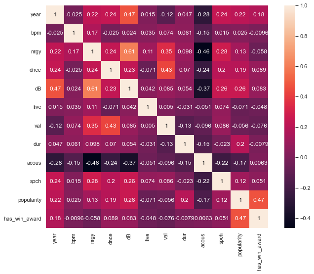

```python
corrmat = data_all_year.corr()
sns.set(rc={'figure.figsize':(11.7,8.27)})
print(sns.heatmap(corrmat, annot = True, square = True))
```

terdapat korelasi yang cukup besar antara energy dan dB; has_win_award dan popularity; dan year dan db. korelasi antara val dan dance juga besar

### Bagaimana pengaruh fitur durasi waktu ke fitur popularitas lagu? Apakah terdapat durasi tertentu yang dapat membuat popularitas lagu semakin tinggi

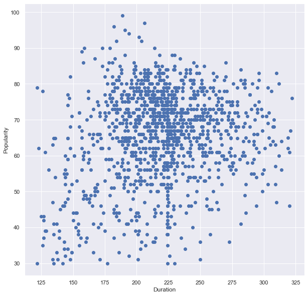

```python
plt.figure(figsize=(10,10))
plt.scatter(data_all_year["dur"],data_all_year["popularity"])
plt.xlabel('Duration')
plt.ylabel('Popularity')
plt.show()
```

Popularity tertinggi pada durasi sekitar 200 detik. Berdasarkan matriks korelasi, duration seharusnya tidak terlalu berpengaruh pada popularity, dengan nilai korelasi 0.2

## Feature Scaling

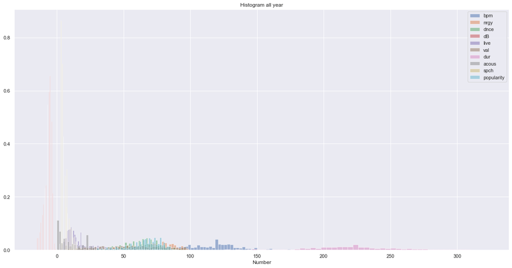

```python
x_dummy = data_all_year.drop(["title", "artist", "genre", "year","has_win_award"], axis=1)

# Visualisasi Histogram
# Set histogram untuk kedua region
plt.figure(figsize=(20,10))
plt.title("Histogram all year", fontsize=12)
plt.hist(x_dummy["bpm"], alpha=0.5, bins=50, density=True, label="bpm")
plt.hist(x_dummy["nrgy"], alpha=0.5, bins=50, density=True, label="nrgy")
plt.hist(x_dummy["dnce"], alpha=0.5, bins=50, density=True, label="dnce")
plt.hist(x_dummy["dB"], alpha=0.5, bins=50, density=True, label="dB")
plt.hist(x_dummy["live"], alpha=0.5, bins=50, density=True, label="live")
plt.hist(x_dummy["val"], alpha=0.5, bins=50, density=True, label="val")
plt.hist(x_dummy["dur"], alpha=0.5, bins=50, density=True, label="dur")
plt.hist(x_dummy["acous"], alpha=0.5, bins=50, density=True, label="acous") # mm
plt.hist(x_dummy["spch"], alpha=0.5, bins=50, density=True, label="spch") # mm
plt.hist(x_dummy["popularity"], alpha=0.5, bins=50, density=True, label="popularity")

plt.xlabel("Number")
plt.ylabel("")
plt.legend()
plt.show()
```

Berdasarkan histogram diatas, kami menggunakan Standardization dalam feature scaling karena mayoritas fitur memiliki distribusi gaussian

```python
from sklearn.preprocessing import StandardScaler, MinMaxScaler
```

## Models

### Lakukan klasifikasi genre lagu menggunakan fitur yang cocok menurut Anda! Apakah model klasifikasi Anda sudah cukup memuaskan?

```python
from sklearn.metrics import precision_score, \
    recall_score, classification_report, \
    accuracy_score, f1_score, ConfusionMatrixDisplay

def performance(actual, predicted):
    print("Hasil Evaluasi:\n\n%s\n" % (classification_report(actual, predicted)))
    print('Accuracy:', accuracy_score(actual, predicted))
    print('Precision Macro Average:', precision_score(actual, predicted, average='macro'))
    print('Precision Micro Average:', precision_score(actual, predicted, average='micro'))
    print('Recall Macro Average:', recall_score(actual, predicted, average='macro'))
    print('Recall Micro Average:', recall_score(actual, predicted, average='micro'))
    print('F1 Macro Average:', f1_score(actual, predicted, average='macro'))
    print('F1 Micro Average:', f1_score(actual, predicted, average='micro'))
```

```python
genre_count = pd.DataFrame(data_all_year['genre'].value_counts())
print(genre_count)
```

```
                           genre
dance pop                    444
adult standards              105
album rock                    78
pop                           71
canadian pop                  43
boy band                      30
big room                      23
glam rock                     23
barbadian pop                 22
brill building pop            20
electropop                    17
europop                       17
british soul                  16
dance rock                    15
atl hip hop                   13
neo mellow                    13
bubblegum dance               13
canadian contemporary r&b     11
art pop                       10
disco                         10
art rock                       9
british invasion               9
east coast hip hop             8
complextro                     7
eurodance                      7
hip pop                        7
deep adult standards           7
hip hop                        7
australian pop                 6
edm                            6
permanent wave                 6
australian dance               6
latin                          5
dfw rap                        5
soft rock                      5
classic soul                   5
mellow gold                    4
brostep                        4
celtic rock                    4
```

[output cut: 82 more lines]

```
britpop                        1
cowboy western                 1
native american                1
danish pop                     1
irish singer-songwriter        1
louisiana blues                1
german alternative rock        1
boogaloo                       1
aussietronica                  1
alternative rock               1
british blues                  1
canadian folk                  1
british dance band             1
classic girl group             1
dirty south rap                1
```

```python
data_for_genre = data_all_year.copy()
genre_count = data_for_genre['genre'].value_counts()
deleted_genre = genre_count[genre_count.values < 6]
deleted_genre = deleted_genre.index.tolist()
data_for_genre = data_for_genre[~(data_for_genre.genre.isin(deleted_genre))]
```

```python
genre_count = pd.DataFrame(data_for_genre['genre'].value_counts())
print(genre_count)
```

```
                           genre
dance pop                    444
adult standards              105
album rock                    78
pop                           71
canadian pop                  43
boy band                      30
glam rock                     23
big room                      23
barbadian pop                 22
brill building pop            20
europop                       17
electropop                    17
british soul                  16
dance rock                    15
neo mellow                    13
bubblegum dance               13
atl hip hop                   13
canadian contemporary r&b     11
disco                         10
art pop                       10
british invasion               9
art rock                       9
east coast hip hop             8
deep adult standards           7
hip pop                        7
hip hop                        7
eurodance                      7
complextro                     7
australian pop                 6
edm                            6
permanent wave                 6
australian dance               6
```

Drop title dan artist karena tidak relevan. Menggunakan standard scaler seperti yang sudah ditentukan di tahap sebelumnya.

```python
x_genre = data_for_genre.drop(["title", "artist", "genre"], axis=1)
y_genre = data_for_genre["genre"]

standard_scaler = StandardScaler()
x_genre_norm = pd.DataFrame(standard_scaler.fit_transform(x_genre), columns=x_genre.columns)
```

Oversampling menggunakan SMOTE

```python
#SMOTE
from imblearn.over_sampling import BorderlineSMOTE

smote = BorderlineSMOTE(k_neighbors=5)
x_genre_norm, y_genre = smote.fit_resample(x_genre_norm, y_genre)
genre_count = y_genre.value_counts()
print(genre_count)
```

```
dance rock                   444
british soul                 444
barbadian pop                444
art pop                      444
atl hip hop                  444
deep adult standards         444
permanent wave               444
album rock                   444
art rock                     444
pop                          444
neo mellow                   444
complextro                   444
british invasion             444
edm                          444
electropop                   444
adult standards              444
canadian contemporary r&b    444
australian pop               444
australian dance             444
europop                      444
boy band                     444
glam rock                    444
hip hop                      444
big room                     444
brill building pop           444
east coast hip hop           444
hip pop                      444
disco                        444
bubblegum dance              444
canadian pop                 444
dance pop                    444
eurodance                      7
Name: genre, dtype: int64
```

```python
from sklearn.model_selection import train_test_split
x_train, x_test, y_train, y_test = train_test_split(x_genre_norm, y_genre, test_size = 0.2, random_state = 123)
```

Klasifikasi menggunakan RandomForest

```
Hasil Evaluasi:

                           precision    recall  f1-score   support

          adult standards       0.93      0.93      0.93        97
               album rock       0.87      0.95      0.91        84
                  art pop       0.99      1.00      0.99        92
                 art rock       1.00      0.99      0.99        85
              atl hip hop       0.99      1.00      1.00       107
         australian dance       1.00      1.00      1.00        80
           australian pop       1.00      1.00      1.00        94
            barbadian pop       0.99      1.00      0.99        82
                 big room       0.99      1.00      0.99        90
                 boy band       1.00      0.99      0.99        80
       brill building pop       0.98      1.00      0.99       100
         british invasion       1.00      0.99      0.99        97
             british soul       1.00      0.97      0.98        86
          bubblegum dance       1.00      1.00      1.00        78
canadian contemporary r&b       0.98      1.00      0.99        85
             canadian pop       0.94      0.94      0.94        90
               complextro       1.00      1.00      1.00        94
                dance pop       0.94      0.74      0.83       100
               dance rock       0.97      1.00      0.99       103
     deep adult standards       1.00      1.00      1.00        99
                    disco       1.00      1.00      1.00        83
       east coast hip hop       0.99      1.00      0.99        81
                      edm       1.00      1.00      1.00        64
               electropop       1.00      0.98      0.99        92
                eurodance       0.00      0.00      0.00         1
                  europop       0.97      0.99      0.98        91
                glam rock       1.00      0.98      0.99        84
                  hip hop       1.00      1.00      1.00        79
                  hip pop       0.96      1.00      0.98       102
               neo mellow       0.98      1.00      0.99        91
           permanent wave       1.00      1.00      1.00        81
                      pop       0.91      0.95      0.93        83

                 accuracy                           0.98      2755
                macro avg       0.95      0.95      0.95      2755
             weighted avg       0.98      0.98      0.98      2755


Accuracy: 0.9789473684210527
Precision Macro Average: 0.9490299297630268
Precision Micro Average: 0.9789473684210527
Recall Macro Average: 0.9497022595903448
Recall Micro Average: 0.9789473684210527
F1 Macro Average: 0.9488725587406674
F1 Micro Average: 0.9789473684210527
```

```
<sklearn.metrics._plot.confusion_matrix.ConfusionMatrixDisplay at 0x27268f70>
```

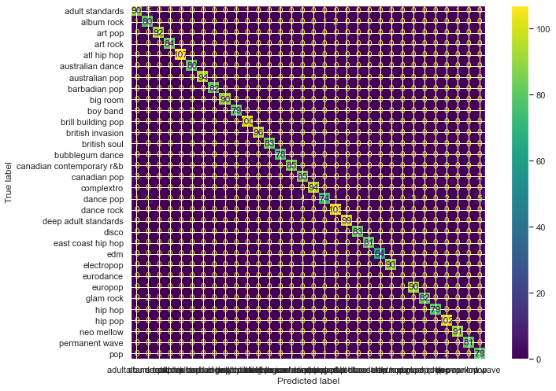

```python
from sklearn.ensemble import RandomForestClassifier
from sklearn.model_selection import RepeatedStratifiedKFold, cross_validate

rf = RandomForestClassifier(max_depth=300, n_estimators = 100)
rf.fit(x_train, y_train)
rf_predict = rf.predict(x_test)
performance(y_test, rf_predict)
ConfusionMatrixDisplay.from_estimator(rf, x_test, y_test)
```

```python
# Cross validation
cv=RepeatedStratifiedKFold(n_splits=10, n_repeats=3, random_state=1)
scoring=['accuracy','precision_micro','precision_macro','recall_micro','recall_macro']
scores = cross_validate(rf, x_train, y_train, scoring=scoring, cv=cv, n_jobs=-1, error_score="raise")
print('Mean Accuracy: %.4f' % np.mean(scores['test_accuracy']))
print('Mean Precision Micro: %.4f' % np.mean(scores['test_precision_micro']))
print('Mean Recall Micro: %.4f' % np.mean(scores['test_recall_micro']))
print('Mean Precision Macro: %.4f' % np.mean(scores['test_precision_macro']))
print('Mean Recall Macro: %.4f' % np.mean(scores['test_recall_macro']))
print()
```

```
Mean Accuracy: 0.9785
Mean Precision Micro: 0.9785
Mean Recall Micro: 0.9785
Mean Precision Macro: 0.9598
Mean Recall Macro: 0.9604
```

Menggunakan MLPClassifier

```
Hasil Evaluasi:

                           precision    recall  f1-score   support

          adult standards       0.90      0.88      0.89        97
               album rock       0.87      0.95      0.91        84
                  art pop       0.97      1.00      0.98        92
                 art rock       1.00      0.99      0.99        85
              atl hip hop       0.97      1.00      0.99       107
         australian dance       1.00      1.00      1.00        80
           australian pop       0.98      1.00      0.99        94
            barbadian pop       0.96      0.99      0.98        82
                 big room       0.93      0.99      0.96        90
                 boy band       0.93      0.95      0.94        80
       brill building pop       0.98      1.00      0.99       100
         british invasion       1.00      1.00      1.00        97
             british soul       0.96      0.94      0.95        86
          bubblegum dance       0.97      1.00      0.99        78
canadian contemporary r&b       0.99      1.00      0.99        85
             canadian pop       0.98      0.92      0.95        90
               complextro       0.99      1.00      0.99        94
                dance pop       0.85      0.35      0.50       100
               dance rock       0.95      0.99      0.97       103
     deep adult standards       1.00      1.00      1.00        99
                    disco       0.95      0.96      0.96        83
       east coast hip hop       0.98      1.00      0.99        81
                      edm       0.98      1.00      0.99        64
               electropop       0.99      0.98      0.98        92
                eurodance       0.00      0.00      0.00         1
                  europop       0.97      0.98      0.97        91
                glam rock       0.91      0.95      0.93        84
                  hip hop       0.99      1.00      0.99        79
                  hip pop       1.00      1.00      1.00       102
               neo mellow       0.98      1.00      0.99        91
           permanent wave       1.00      1.00      1.00        81
                      pop       0.73      0.94      0.82        83

                 accuracy                           0.96      2755
                macro avg       0.93      0.93      0.92      2755
             weighted avg       0.96      0.96      0.95      2755


Accuracy: 0.9571687840290382
Precision Macro Average: 0.9270817933092002
Precision Micro Average: 0.9571687840290382
Recall Macro Average: 0.9300078400157494
Recall Micro Average: 0.9571687840290382
F1 Macro Average: 0.924632522911909
F1 Micro Average: 0.9571687840290382
```

```
<sklearn.metrics._plot.confusion_matrix.ConfusionMatrixDisplay at 0x27512c70>
```

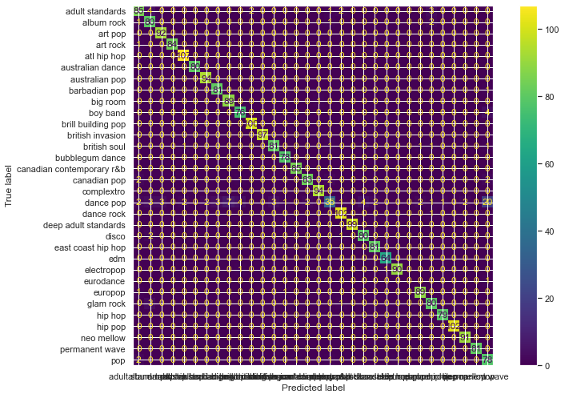

```python
from sklearn.neural_network import MLPClassifier
mlp = MLPClassifier(
    solver='sgd',
    activation='relu',
    alpha=0.00001,
    learning_rate='constant',
    hidden_layer_sizes=(30,30,30),
    random_state=2021,
    max_iter=1000
)

mlp.fit(x_train, y_train)
mlp_predict = mlp.predict(x_test)
performance(y_test, mlp_predict)
ConfusionMatrixDisplay.from_estimator(mlp, x_test, y_test)
```

### Buatlah cluster-cluster dari lagu menggunakan fitur yang cocok menurut Anda! Apakah cluster yang dihasilkan dapat merepresentasikan lagu berdasarkan suatu fakta?

#### Dimensionality Reduction then Clustering

```python
# Data
data_all_year_copy = data_all_year.copy()
data_copy = data_all_year_copy.drop(columns=['title', 'artist', 'genre', 'year'])
data_copy_1 = data_copy.copy()
data_copy.head(5)
```

|  | bpm | nrgy | dnce | dB | live | val | dur | acous | spch | popularity | has_win_award |
| --- | --- | --- | --- | --- | --- | --- | --- | --- | --- | --- | --- |
| 0 | 116.000000 | 34.0 | 55.0 | -9.0 | 10.000000 | 47.0 | 155.0 | 75.000000 | 3.0 | 72.0 | 0.0 |
| 1 | 118.848031 | 34.0 | 42.0 | -11.0 | 17.992126 | 78.0 | 123.0 | 22.514961 | 4.0 | 62.0 | 0.0 |
| 2 | 81.000000 | 49.0 | 26.0 | -9.0 | 34.000000 | 40.0 | 162.0 | 22.514961 | 4.0 | 61.0 | 0.0 |
| 3 | 82.000000 | 43.0 | 49.0 | -12.0 | 12.000000 | 66.0 | 151.0 | 70.000000 | 6.0 | 60.0 | 0.0 |
| 4 | 79.000000 | 38.0 | 56.0 | -9.0 | 13.000000 | 62.0 | 158.0 | 67.000000 | 3.0 | 60.0 | 0.0 |

```python
from sklearn.preprocessing import StandardScaler
from sklearn.decomposition import PCA
from sklearn.manifold import TSNE

# Dimensionality Reduction
X_1 = data_copy.values
X_std_1 = StandardScaler().fit_transform(X_1)
tsne = TSNE(n_components=2, verbose=1, random_state=123)
skl_tsne = tsne.fit_transform(X_std_1)
y = data_copy['popularity'].values #Target song popularity
pca = PCA(n_components=2)
skl_pca = pca.fit_transform(X_std_1)
skl_pca.shape
```

```
[t-SNE] Computing 91 nearest neighbors...
[t-SNE] Indexed 1270 samples in 0.002s...
[t-SNE] Computed neighbors for 1270 samples in 0.064s...
[t-SNE] Computed conditional probabilities for sample 1000 / 1270
[t-SNE] Computed conditional probabilities for sample 1270 / 1270
[t-SNE] Mean sigma: 1.019455
[t-SNE] KL divergence after 250 iterations with early exaggeration: 69.717850
[t-SNE] KL divergence after 1000 iterations: 1.342243
```

```
(1270, 2)
```

```python
skl_tsne
```

```
array([[-14.964118, -37.76463 ],
       [-10.700852, -40.386345],
       [-11.843589, -30.829967],
       ...,
       [ 11.315552, -10.281593],
       [ 19.089233,  19.557745],
       [  4.922932, -25.024456]], dtype=float32)
```

```python
skl_pca
```

```
array([[ 3.0875027 ,  0.40277005],
       [ 2.44900468, -1.05968954],
       [ 2.56422433, -0.53791613],
       ...,
       [-1.06753612,  0.06667962],
       [-0.72105714, -0.28857845],
       [ 0.66630807,  0.41150334]])
```

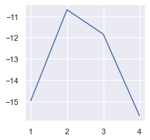

```python
import numpy as np
# Figure X1 TSNE
plt.figure(figsize=(3, 3))
x_ax = np.array([1, 2, 3, 4])
y_ax = np.array([skl_tsne[0][0], skl_tsne[1][0], skl_tsne[2][0], skl_tsne[3][0]])
plt.plot(x_ax, y_ax)
plt.show()
```

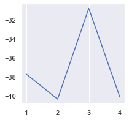

```python
# Figure X2 TSNE
plt.figure(figsize=(3, 3))
x_ax = np.array([1, 2, 3, 4])
y_ax = np.array([skl_tsne[0][1], skl_tsne[1][1], skl_tsne[2][1], skl_tsne[3][1]])
plt.plot(x_ax, y_ax)
plt.show()
```

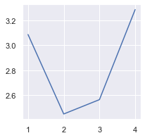

```python
# Figure X1 PCA
plt.figure(figsize=(3, 3))
x_ax = np.array([1, 2, 3, 4])
y_ax = np.array([skl_pca[0][0], skl_pca[1][0], skl_pca[2][0], skl_pca[3][0]])
plt.plot(x_ax, y_ax)
plt.show()
```

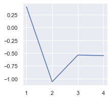

```python
# Figure X2 PCA
plt.figure(figsize=(3, 3))
x_ax = np.array([1, 2, 3, 4])
y_ax = np.array([skl_pca[0][1], skl_pca[1][1], skl_pca[2][1], skl_pca[3][1]])
plt.plot(x_ax, y_ax)
plt.show()
```

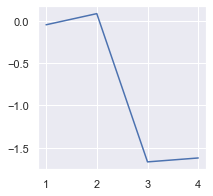

```python
plt.figure(figsize=(3, 3))
x_ax = np.array([1, 2, 3, 4])
y_ax = np.array([X_std_1[0][0], X_std_1[1][0], X_std_1[2][0], X_std_1[3][0]])
plt.plot(x_ax, y_ax)
plt.show()
```

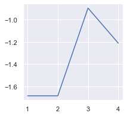

```python
plt.figure(figsize=(3, 3))
x_ax = np.array([1, 2, 3, 4])
y_ax = np.array([X_std_1[0][1], X_std_1[1][1], X_std_1[2][1], X_std_1[3][1]])
plt.plot(x_ax, y_ax)
plt.show()
```

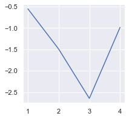

```python
plt.figure(figsize=(3, 3))
x_ax = np.array([1, 2, 3, 4])
y_ax = np.array([X_std_1[0][2], X_std_1[1][2], X_std_1[2][2], X_std_1[3][2]])
plt.plot(x_ax, y_ax)
plt.show()
```

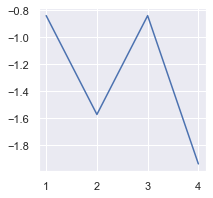

```python
plt.figure(figsize=(3, 3))
x_ax = np.array([1, 2, 3, 4])
y_ax = np.array([X_std_1[0][3], X_std_1[1][3], X_std_1[2][3], X_std_1[3][3]])
plt.plot(x_ax, y_ax)
plt.show()
```

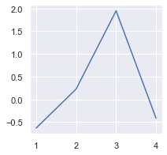

```python
plt.figure(figsize=(3, 3))
x_ax = np.array([1, 2, 3, 4])
y_ax = np.array([X_std_1[0][4], X_std_1[1][4], X_std_1[2][4], X_std_1[3][4]])
plt.plot(x_ax, y_ax)
plt.show()
```

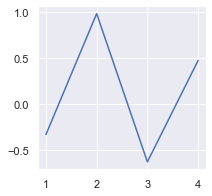

```python
plt.figure(figsize=(3, 3))
x_ax = np.array([1, 2, 3, 4])
y_ax = np.array([X_std_1[0][5], X_std_1[1][5], X_std_1[2][5], X_std_1[3][5]])
plt.plot(x_ax, y_ax)
plt.show()
```

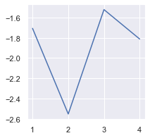

```python
plt.figure(figsize=(3, 3))
x_ax = np.array([1, 2, 3, 4])
y_ax = np.array([X_std_1[0][6], X_std_1[1][6], X_std_1[2][6], X_std_1[3][6]])
plt.plot(x_ax, y_ax)
plt.show()
```

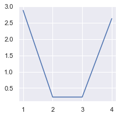

```python
plt.figure(figsize=(3, 3))
x_ax = np.array([1, 2, 3, 4])
y_ax = np.array([X_std_1[0][7], X_std_1[1][7], X_std_1[2][7], X_std_1[3][7]])
plt.plot(x_ax, y_ax)
plt.show()
```

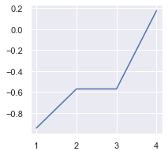

```python
plt.figure(figsize=(3, 3))
x_ax = np.array([1, 2, 3, 4])
y_ax = np.array([X_std_1[0][8], X_std_1[1][8], X_std_1[2][8], X_std_1[3][8]])
plt.plot(x_ax, y_ax)
plt.show()
```

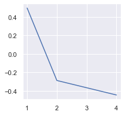

```python
plt.figure(figsize=(3, 3))
x_ax = np.array([1, 2, 3, 4])
y_ax = np.array([X_std_1[0][9], X_std_1[1][9], X_std_1[2][9], X_std_1[3][9]])
plt.plot(x_ax, y_ax)
plt.show()
```

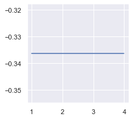

```python
plt.figure(figsize=(3, 3))
x_ax = np.array([1, 2, 3, 4])
y_ax = np.array([X_std_1[0][10], X_std_1[1][10], X_std_1[2][10], X_std_1[3][10]])
plt.plot(x_ax, y_ax)
plt.show()
```

```
[Text(0.5, 1.0, 'Data Copy PCA projection')]
```

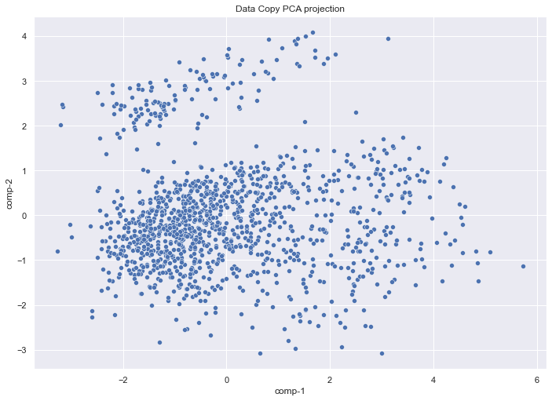

```python
import seaborn as sns

# Visualize PCA
df_pca = pd.DataFrame()
df_pca["comp-1"] = skl_pca[:,0]
df_pca["comp-2"] = skl_pca[:,1]

sns.scatterplot(x="comp-1", y="comp-2",
                data=df_pca).set(title="Data Copy PCA projection")
```

```
[Text(0.5, 1.0, 'Data Copy T-SNE projection')]
```

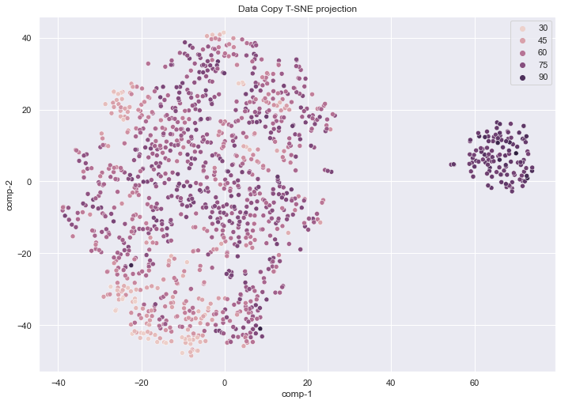

```python
# Visualize T-SNE
df_tsne = pd.DataFrame()
df_tsne["y"] = y
df_tsne["comp-1"] = skl_tsne[:,0]
df_tsne["comp-2"] = skl_tsne[:,1]

sns.scatterplot(x="comp-1", y="comp-2", hue=df_tsne.y.tolist(),
                data=df_tsne).set(title="Data Copy T-SNE projection")
```

Dari kedua proyeksi diatas, **dimensionality reduction menggunakan T-SNE lebih menghasilkan cluster yang bagus** jika digunakan algoritma clustering nantinya ketimbang dengan menggunakan PCA

Dengan T-SNE, hasil clustering lebih solid karena preserve small distance ketimbang PCA yang hasil clusteringnya tersebar karena maximizing variance

```python
# Add colors
colors = ['#34e5eb', '#a534eb', '#34eba8']
```

```python
from sklearn.cluster import KMeans, AgglomerativeClustering
# K-means dan Agglomerative dengan library sklearn

kmeans = KMeans(n_clusters=2)
agg = AgglomerativeClustering(n_clusters=2, affinity='euclidean', linkage='single')
df_tsne['cluster_k'] = kmeans.fit_predict(df_tsne)
df_tsne['cluster_a'] = agg.fit_predict(df_tsne)

# Add colors and clustering
df_tsne['c_k'] = df_tsne.cluster_k.map({0:colors[0],
                                        1:colors[1]})
df_tsne['c_a'] = df_tsne.cluster_a.map({0:colors[0],
                                        1:colors[1]})
```

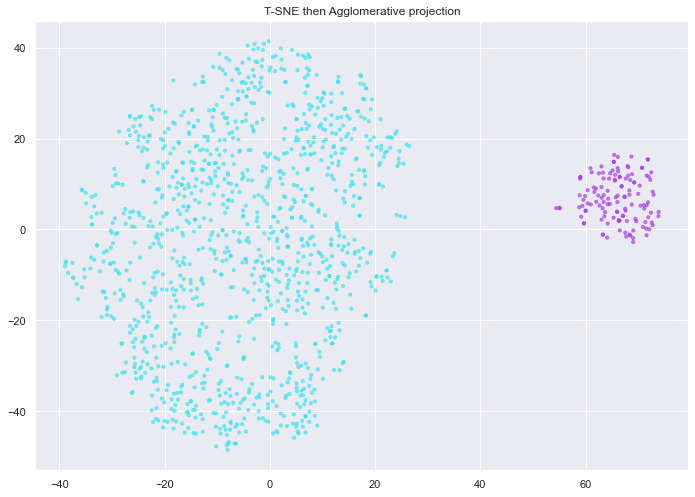

```python
# Proyeksi clustering dengan Agglomerative
plt.scatter(df_tsne['comp-1'], df_tsne['comp-2'],
            c=df_tsne.c_a, alpha = 0.6, s=10)
plt.title("T-SNE then Agglomerative projection")
plt.show()
```

### Buatlah model untuk memprediksi popularity dari suatu lagu! Apakah model yang anda buat dapat dibuat lebih baik lagi?

Setelah mencoba beberapa model regresi, regresi menggunakan random forest memiliki hasil yang paling bagus

```python
from sklearn.preprocessing import StandardScaler, LabelEncoder
from sklearn.linear_model import LinearRegression, Ridge, Lasso, LogisticRegression
from sklearn.model_selection import train_test_split

scaler = StandardScaler()

label=LabelEncoder()

data_all_year['year'] = label.fit_transform(data_all_year['year'])
data_clean = pd.get_dummies(data_all_year, columns =['genre']) #OneHotEncoding atribut genre


features = data_clean.drop(["title", "artist", "popularity","val", "live", "bpm"], axis=1)
target = data_clean['popularity']

display(features.head(5))

features_normalized = pd.DataFrame(scaler.fit_transform(features), columns=features.columns)
x_train, x_test, y_train, y_test = train_test_split(features_normalized, target, train_size = 0.8, random_state=23)
```

|  | year | nrgy | dnce | dB | dur | acous | spch | has_win_award | genre_acoustic blues | genre_acoustic pop | ... | genre_neo mellow | genre_new wave pop | genre_permanent wave | genre_pop | genre_r&b | genre_rock-and-roll | genre_soft rock | genre_tropical house | genre_uk garage | genre_yodeling |
| --- | --- | --- | --- | --- | --- | --- | --- | --- | --- | --- | --- | --- | --- | --- | --- | --- | --- | --- | --- | --- | --- |
| 0 | 46 | 34.0 | 55.0 | -9.0 | 155.0 | 75.000000 | 3.0 | 0.0 | 0 | 0 | ... | 0 | 0 | 0 | 0 | 0 | 0 | 0 | 0 | 0 | 0 |
| 1 | 1 | 34.0 | 42.0 | -11.0 | 123.0 | 22.514961 | 4.0 | 0.0 | 0 | 0 | ... | 0 | 0 | 0 | 0 | 0 | 0 | 0 | 0 | 0 | 0 |
| 2 | 59 | 49.0 | 26.0 | -9.0 | 162.0 | 22.514961 | 4.0 | 0.0 | 0 | 0 | ... | 0 | 0 | 0 | 0 | 0 | 0 | 0 | 0 | 0 | 0 |
| 3 | 57 | 43.0 | 49.0 | -12.0 | 151.0 | 70.000000 | 6.0 | 0.0 | 0 | 0 | ... | 0 | 0 | 0 | 0 | 0 | 0 | 0 | 0 | 0 | 0 |
| 4 | 5 | 38.0 | 56.0 | -9.0 | 158.0 | 67.000000 | 3.0 | 0.0 | 0 | 0 | ... | 0 | 0 | 0 | 0 | 0 | 0 | 0 | 0 | 0 | 0 |

5 rows × 144 columns

```python
data_all_year.shape
```

```
(1270, 15)
```

```python
lr = LinearRegression()
lr.fit(x_train, y_train)
y_pred = lr.predict(x_test)
data = pd.DataFrame({'Target (predicted)': y_pred, 'Target (actual)': y_test})

data_target_only = data[['Target (actual)', 'Target (predicted)']] # Mengambil atribut actual dan predicted saja dari dataframe
display(data_target_only.head())
```

|  | Target (actual) | Target (predicted) |
| --- | --- | --- |
| 84 | 71.0 | 6.939258e+01 |
| 965 | 72.0 | 6.416016e+01 |
| 1073 | 66.0 | 6.498828e+01 |
| 164 | 38.0 | 1.091728e+15 |
| 260 | 55.0 | 6.016016e+01 |

```python
import sklearn.metrics as metrics

mae = metrics.mean_absolute_error(y_test, y_pred)
mse = metrics.mean_squared_error(y_test, y_pred)
rmse = np.sqrt(mse)
r2 = metrics.r2_score(y_test,y_pred)

print("Results of sklearn.metrics:")
print("MAE:",mae)
print("MSE:", mse)
print("RMSE:", rmse)
print("R-Squared:", r2)
```

```
Results of sklearn.metrics:
MAE: 285331957921117.4
MSE: 2.27629918936865e+30
RMSE: 1508740928512463.2
R-Squared: -1.4399780256447371e+28
```

```python
clf = Ridge()
clf.fit(x_train, y_train)

y_pred_ridge = clf.predict(x_test)
r2_ridge = metrics.r2_score(y_test,y_pred_ridge)

print("Results of sklearn.metrics:")
print("R-Squared:", r2_ridge)
```

```
Results of sklearn.metrics:
R-Squared: 0.3062407554457739
```

```python
alpha_max = 0
r2_highest = 0
for alpha in [ 0.0001, 0.01,0.1, 0.15, 0.16, 0.2, 0.5, 1, 2, 5, 10]:
  ls = Lasso(alpha=alpha, max_iter = 10000)
  ls.fit(x_train, y_train)
  y_pred_ls = ls.predict(x_test)
  r2_ls = metrics.r2_score(y_test,y_pred_ls)
  if r2_ls > r2_highest:
    r2_highest = r2_ls
    alpha_max = alpha


print("R-Squared for alpha", alpha_max, ":", r2_highest)
```

```
R-Squared for alpha 0.5 : 0.3794644468526951
```

```python
from sklearn.svm import SVR

regressor_svr = SVR(kernel = 'sigmoid', C = 4)
regressor_svr.fit(x_train, y_train)

y_pred_svr = regressor_svr.predict(x_test)


print("Results of sklearn.metrics:")
print("MAE:",metrics.mean_absolute_error(y_test, y_pred_svr))
print("MSE:", metrics.mean_squared_error(y_test, y_pred_svr))
print("RMSE:", np.sqrt(metrics.mean_squared_error(y_test, y_pred_svr)))
print("R-Squared:", metrics.r2_score(y_test, y_pred_svr))
```

```
Results of sklearn.metrics:
MAE: 7.611560612645577
MSE: 102.51654263726455
RMSE: 10.125045315319065
R-Squared: 0.35148433320104666
```

Random forest menghasilkan regresi paling baik

```python
# Fitting Random Forest Regression to the dataset
from sklearn.ensemble import RandomForestRegressor


regressor_forest = RandomForestRegressor(
    n_estimators = 100,
    random_state = 10,
    criterion = "absolute_error")
regressor_forest.fit(x_train, y_train)

y_pred_forest = regressor_forest.predict(x_test)

print("Results of sklearn.metrics:")
print("MAE:",metrics.mean_absolute_error(y_test, y_pred_forest))
print("MSE:", metrics.mean_squared_error(y_test, y_pred_forest))
print("RMSE:", np.sqrt(metrics.mean_squared_error(y_test, y_pred_forest)))
print("R-Squared:", metrics.r2_score(y_test, y_pred_forest))
```

```
Results of sklearn.metrics:
MAE: 7.058860716721434
MSE: 86.6139653206239
RMSE: 9.306662415744105
R-Squared: 0.452083419621801
```

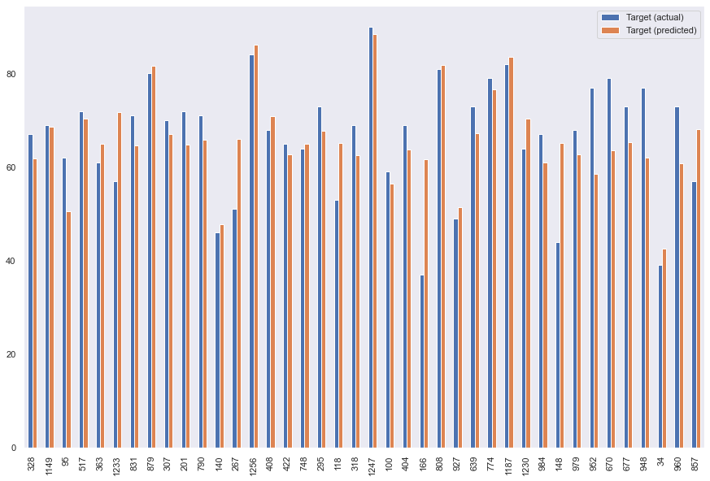

```python
data = pd.DataFrame({'Target (predicted)': y_pred_forest, 'Target (actual)': y_test})
data_target_only = data[['Target (actual)', 'Target (predicted)']] # Mengambil atribut actual dan predicted saja dari dataframe
df_temp = data_target_only.tail(40)
df_temp.plot(kind='bar',figsize=(15,10))
plt.grid(which='major', linestyle='-', linewidth='0.5', color='green')
plt.show()
```

```python
from sklearn.neural_network import MLPRegressor

mlp_reg = MLPRegressor(
    hidden_layer_sizes=(300,300,300),
    max_iter = 300,
    activation = 'logistic',
    solver = 'adam',
    random_state=2021)

mlp_reg.fit(x_train, y_train)
y_pred_mlp = mlp_reg.predict(x_test)

print("Results of sklearn.metrics:")
print("MAE:",metrics.mean_absolute_error(y_test, y_pred_mlp))
print("MSE:", metrics.mean_squared_error(y_test, y_pred_mlp))
print("RMSE:", np.sqrt(metrics.mean_squared_error(y_test, y_pred_mlp)))
print("R-Squared:", metrics.r2_score(y_test, y_pred_mlp))
```

```
Results of sklearn.metrics:
MAE: 8.349940125366606
MSE: 121.42508846692004
RMSE: 11.019305262443728
R-Squared: 0.23186960672411006
```

```python
from sklearn.ensemble import GradientBoostingRegressor
from sklearn.model_selection import GridSearchCV

gradient_regresson = GradientBoostingRegressor(
    loss="absolute_error",
    n_estimators = 1000,
    criterion="friedman_mse",
    max_depth=10
)

param_grid = {'loss': ["absolute_error"],
              'n_estimators': [100,200,300],
              'criterion': ["squared_error"],
              }

grid = GridSearchCV(gradient_regresson, param_grid, refit = True, verbose = 3)

grid.fit(x_train, y_train)
y_pred_gradient = grid.predict(x_test)

# print best parameter after tuning
print("\nBest Param : {}".format(grid.best_params_))
# print how our model looks after hyper-parameter tuning
print("\nBest estimator : {}".format(grid.best_estimator_))

print("Results of sklearn.metrics:")
print("MAE:",metrics.mean_absolute_error(y_test, y_pred_gradient))
print("MSE:", metrics.mean_squared_error(y_test, y_pred_gradient))
print("RMSE:", np.sqrt(metrics.mean_squared_error(y_test, y_pred_gradient)))
print("R-Squared:", metrics.r2_score(y_test, y_pred_gradient))
```

```
Fitting 5 folds for each of 3 candidates, totalling 15 fits
[CV 1/5] END criterion=squared_error, loss=absolute_error, n_estimators=100;, score=0.307 total time=   1.9s
[CV 2/5] END criterion=squared_error, loss=absolute_error, n_estimators=100;, score=0.368 total time=   1.9s
[CV 3/5] END criterion=squared_error, loss=absolute_error, n_estimators=100;, score=0.385 total time=   1.8s
[CV 4/5] END criterion=squared_error, loss=absolute_error, n_estimators=100;, score=0.272 total time=   1.7s
[CV 5/5] END criterion=squared_error, loss=absolute_error, n_estimators=100;, score=0.268 total time=   1.7s
[CV 1/5] END criterion=squared_error, loss=absolute_error, n_estimators=200;, score=0.323 total time=   3.4s
[CV 2/5] END criterion=squared_error, loss=absolute_error, n_estimators=200;, score=0.394 total time=   3.5s
[CV 3/5] END criterion=squared_error, loss=absolute_error, n_estimators=200;, score=0.375 total time=   3.4s
[CV 4/5] END criterion=squared_error, loss=absolute_error, n_estimators=200;, score=0.304 total time=   3.7s
[CV 5/5] END criterion=squared_error, loss=absolute_error, n_estimators=200;, score=0.296 total time=   3.1s
[CV 1/5] END criterion=squared_error, loss=absolute_error, n_estimators=300;, score=0.293 total time=   4.9s
[CV 2/5] END criterion=squared_error, loss=absolute_error, n_estimators=300;, score=0.405 total time=   4.7s
[CV 3/5] END criterion=squared_error, loss=absolute_error, n_estimators=300;, score=0.432 total time=   5.0s
[CV 4/5] END criterion=squared_error, loss=absolute_error, n_estimators=300;, score=0.284 total time=   4.9s
[CV 5/5] END criterion=squared_error, loss=absolute_error, n_estimators=300;, score=0.290 total time=   5.0s

Best Param : {'criterion': 'squared_error', 'loss': 'absolute_error', 'n_estimators': 300}

Best estimator : GradientBoostingRegressor(criterion='squared_error', loss='absolute_error',
                          max_depth=10, n_estimators=300)
Results of sklearn.metrics:
MAE: 7.307612093136352
MSE: 97.67223279717051
RMSE: 9.882926327620302
R-Squared: 0.3821292490878935
```